# PREPROCESADO DE DATOS

### CONTRASTE DE HIPÓTESIS

Siguiendo con la línea expuesta desde el inicio del análisis, a la que vamos a sumar las variables signiticativas que acabamos de observar a lo largo de los modelos de regresión, vamos a tratar la creencia de qué los vinos de calidad (Calidad_BM = 1 o quality >= 5) tienen una mayor acidez que los vinos de calidad baja (Calidad_BM = 0 o quality < 5). Para ello, veremos si los vinos de calidad disponen de mejor acidez NO volátil (fixed.acidity), ácido cítrico (citric.acid) que los vinos de una calidad baja.

En este apartado se va a llevar a cabo un contraste de hipótesis de dos muestras independientes sobre el valor medio de fixed.acidity/citric.acid/volatile.acidity de una muestra de vinos de calidad y de una muestra de vinos de baja calidad con varianzas desconocidas por lo que deberemos, previamente a la realización del contraste de hipótesis, llevar a cabo un Test de varianzas para observar si las varianzas de ambas muestras son iguales o no con el fin de aplicar el estadístico correcto en el posterior contraste de hipótesis sobre la media de las variables.

El primer paso a llevar a cabo previo a cualquier tipo de contraste de hipótesis en este caso es la obtención de las muestras de los vinos que presentan un valor más alto y más bajo de calidad, en función del valor de calidad indistintivamente:

```r
# Establezco una condición de calidad:
condicion_calidad <- base.datos$quality >= 5

# Aplico la condición de calidad sobre la muestra inicial y obtengo las dos muestras independientes:
alta_calidad <- base.datos[condicion_calidad, ]
baja_calidad <- base.datos[!condicion_calidad, ]

paste("La muestra de ALTA calidad contiene n = ",nrow(alta_calidad), " campos")
```

```
## [1] "La muestra de ALTA calidad contiene n =  1536  campos"
```

```r
paste("La muestra de BAJA calidad contiene n = ",nrow(baja_calidad), " campos")
```

```
## [1] "La muestra de BAJA calidad contiene n =  63  campos"
```

Una vez disponemos de las muestras y del valor n de cada una de ellas, procedemos con la pregunta de investigación.

La estructura de dichas preguntas cobra importancia ya que van a dar pié al establecimiento de las hipótesis (nula y alternativa) correspondientes y de fijar en cierta manera que tipología de contraste (unilateral, bilateral) vamos a tener. Las preguntas son por tanto:

Variable fixed.acidity: ¿El valor medio de la variable fixed.acidity de los vinos de calidad es significativamente mayor al valor medio de la variable fixed.acidity de los vinos de baja calidad?

Variable citric.acid: ¿El valor medio de la variable citric.acid de los vinos de calidad es significativamente mayor al valor medio de la variable citric.acid de los vinos de baja calidad?

Variable volatile.acidity: ¿El valor medio de la variable volatile.acidity de los vinos de calidad es significativamente mayor al valor medio de la variable volatile.acidity de los vinos de baja calidad?

Queremos observar en cada caso, si el valor medio de cada variable para la muestra de buenos de caldiad es mayor al valor medio de cada variable para la muestra de vinos de baja calidad, lo que nos llevará a establecer un contraste de hipótesis Unilateral por la derecha como veremos más adelante.

El siguiente punto sería la observación de la distribución de frecuencias de cada una de las variables en cada una de las muestras (alta_calidad y baja_calidad respectivamente) para observar si podemos asumir normalidad en las distribuciones y aplicar el test estadístico correspondiente y/o asumir la teoría del Teorema del Límite central para evitar llevar a cabo un test no paramétrico en caso de no normalidad.

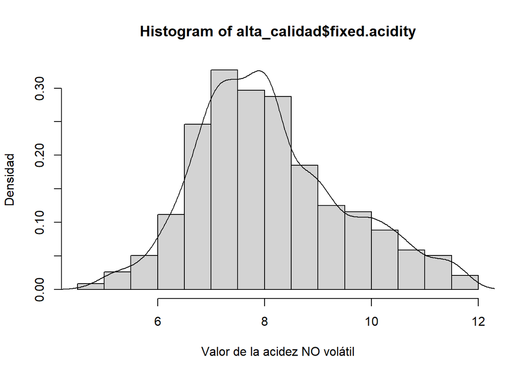

```r
# ALTA CALIDAD:

# fixed.acidity
hist(alta_calidad$fixed.acidity, freq = F, ylab = "Densidad", xlab = "Valor de la acidez NO volátil")
lines(density(alta_calidad$fixed.acidity))
```

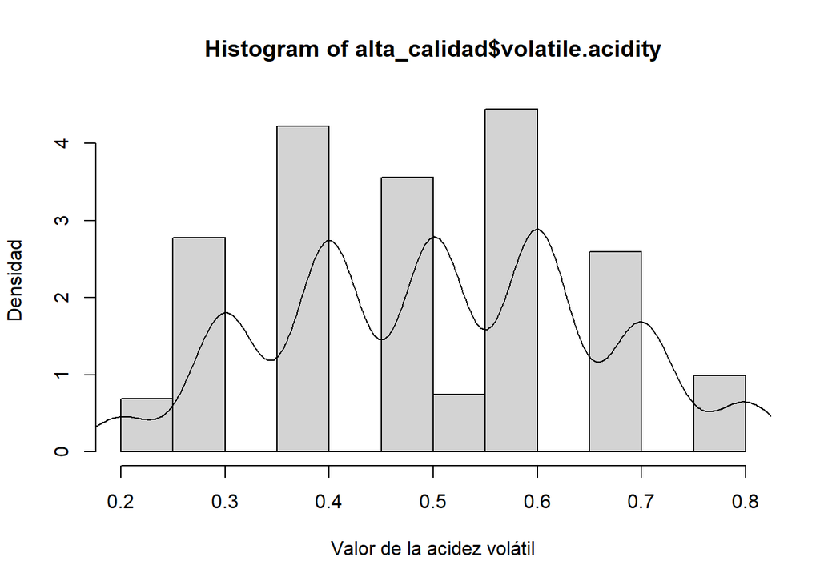

```r
# volatile.acidity
hist(alta_calidad$volatile.acidity, freq = F, ylab = "Densidad", xlab = "Valor de la acidez volátil")
lines(density(alta_calidad$volatile.acidity))
```

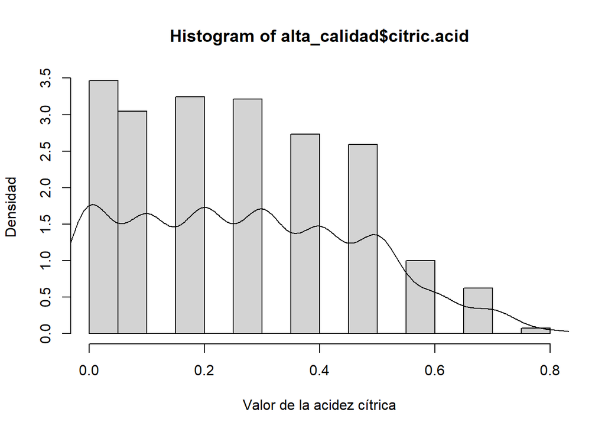

```r
# citric.acid
hist(alta_calidad$citric.acid, freq = F, ylab = "Densidad", xlab = "Valor de la acidez cítrica")
lines(density(alta_calidad$citric.acid))
```

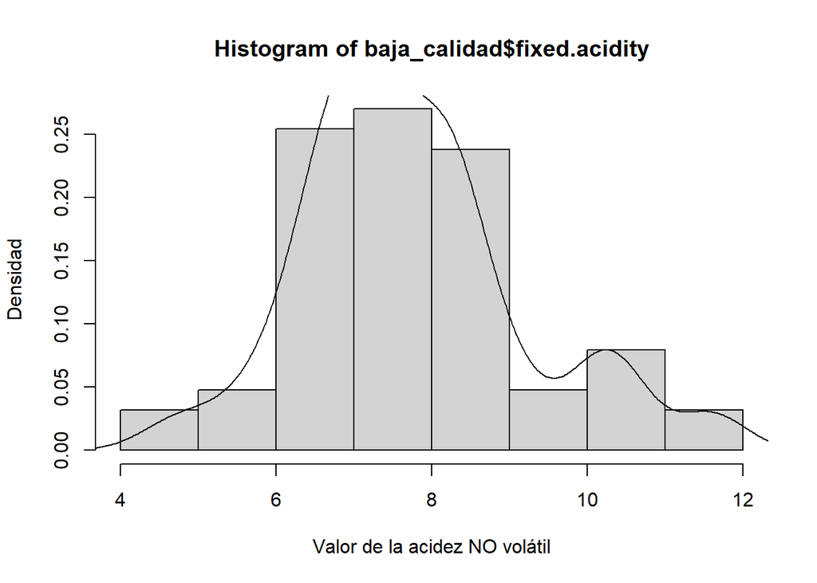

```r
# BAJA CALIDAD:

# fixed.acidity
hist(baja_calidad$fixed.acidity, freq = F, ylab = "Densidad", xlab = "Valor de la acidez NO volátil")
lines(density(baja_calidad$fixed.acidity))
```

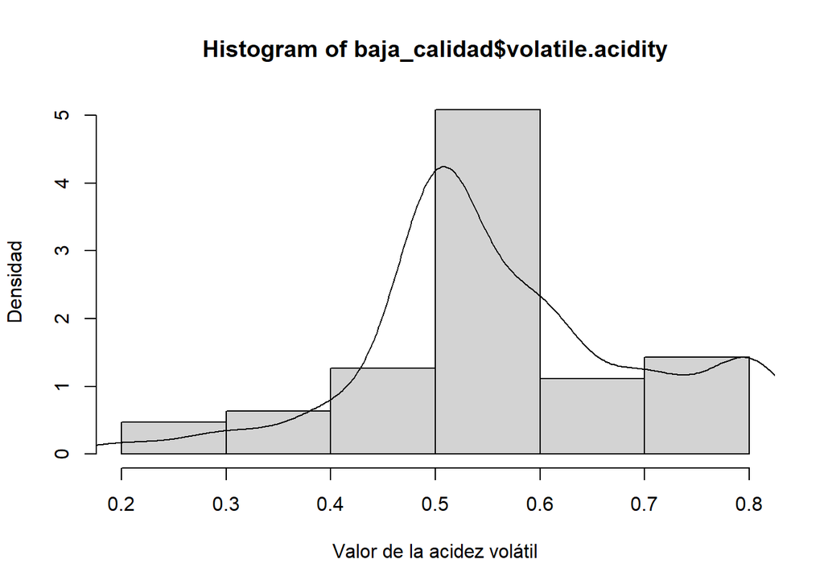

```r
# volatile.acidity
hist(baja_calidad$volatile.acidity, freq = F, ylab = "Densidad", xlab = "Valor de la acidez volátil")
lines(density(baja_calidad$volatile.acidity))
```

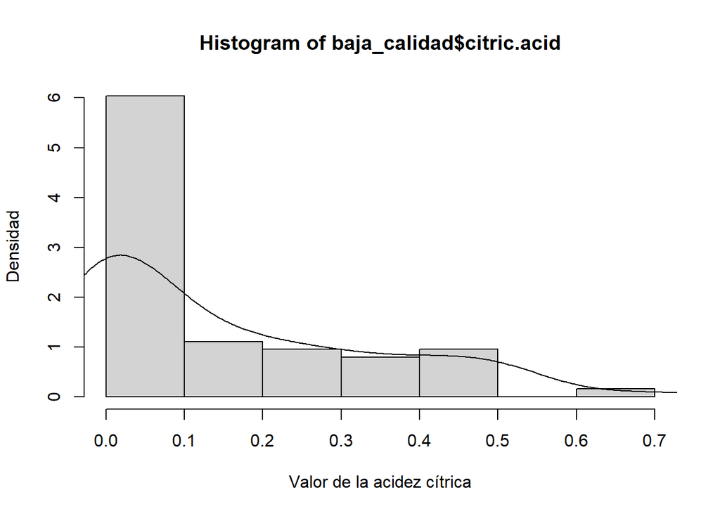

```r
# citric.acid
hist(baja_calidad$citric.acid, freq = F, ylab = "Densidad", xlab = "Valor de la acidez cítrica")
lines(density(baja_calidad$citric.acid))
```

A pesar de únicamente haber mostrado los diagramas de frecuencias, podemos observar como un valor de Shapiro.test o cualquier otro test de normalidad, nos conllevaría a identificar una distribución NO normal…

Para evitar de la realización de Tests no paramétricos para llevar a cabo el contraste de hipótesis y todo lo que ello comporta, haremos cita de y uso del TEOREMA DEL LÍMITE CENTRAL. Dicho teorema establece que el contraste de hipótesis sobre la media de una muestra (que es precisamente el hecho que estamos evaluando en nuestro caso con las muestras de alta_calidad y baja_calidad) se aproxima a una distribución normal aunque la población original no siga dicha distribución (pues lo hemos visto con la representación de la densidad), siempre que el tamaño de la muestra “n” sea suficientemente grande, esto es, superior a 30 elementos.

En nuestro caso, las muestras disponen de unos valores de n de 63 y 1536 respectivamente para baja_calidad y alta_calidad tal y como ya se ha mostrado con anterioridad. Por tanto, la aplicación del Teorema del Límite Central es válida y asumimos que las disribuciones se pueden aproximar a una distribución Normal para el contraste. Esto nos facilita el proceso significativamente…

Una vez tenemos claras y definidas las muestras, las distribuciones que siguen las variables que vamos a analizar dentro de la muestra y las preguntas de investigación para cada variable sobre la que vamos a constatar en contraste de hipótesis, procedemos con el establecimiento de las hipótesis Nula y alternativa.

H0: Media de los valores de fixed.acidity/volatile.acidity/citric.acid en alta_calidad = Media de los valores de fixed.acidity/volatile.acidity/citric.acid en baja_calidad

H1: Media de los valores de fixed.acidity/volatile.acidity/citric.acid en alta_calidad > Media de los valores de fixed.acidity/volatile.acidity/citric.acid en baja_calidad

Como vemos, nos encontramos frente un contraste unitaleral por la derecha. En este punto, procedemos con el contraste de hipótesis.

Llegados a este punto, vamos a proceder con el dicho contraste de hipótesis bajo las consideraciones que hemos ido justificado en los pasos previos de este ejercicio. Antes, debido al desconocimiento de la varianza de las muestras, debemos proceder con un Test de Varianzas para cada muestra. Para aplicar el estadístico adecuado, hay que comprobar si las varianzas de las dos poblaciones son iguales o no. Para ello, aplicamos primero el test de igualdad de varianzas.

En este punto vamos a suponer una hipótesis nula y alternativa sobre el valor de la varianza de cada población sobre cada una de las 3 variables:

H0: (varianza alta_calidad[fixed.acidity/volatile.acidity/citric.acid]) = (varianza baja_calidad[fixed.acidity/volatile.acidity/citric.acid])

H1: (varianza alta_calidad[fixed.acidity/volatile.acidity/citric.acid]) != (varianza baja_calidad[fixed.acidity/volatile.acidity/citric.acid])

En este punto procederemos con el Test de Varianzas para cada una de las variables anteriores sobre ambas muestras:

```r
funcion_varianzas <- function(alta, baja){

   # Definición de variables necesarias para el cómputo:
   alfa = 0.05
   mean1 <- mean(alta) # media de la variable en la muestra alta calidad
   mean2 <- mean(baja) # media de la variable en la muestra baja calidad
   n1 <- length(alta)
   n2 <- length(baja)
   s1 <- sd(alta) # d.estándar
   s2 <- sd(baja) # d.estándar

   # Muestro por pantalla las variables anteriores:
   print("Mean_Alta|Mean_Baja|S_Alta|S_Baja|Total_muestra_Alta|Total_muestra_Baja")
   print(c(mean1, mean2, s1, s2, n1, n2))


   # Calculo estadístico y valores de intérvalo inferior y superior:
   fobs = s1^2/s2^2
   fcritL <- qf(alfa/2, df1=n1-1, df2=n2-2)
   fcritU <- qf(1-alfa/2, df1=n1-1, df2=n2-2)
   pvalue <- min(pf(fobs, df1=n1-1, df2=n2-2, lower.tail = FALSE), pf(fobs, df1=n1-1, df2=n2-2))*2

   # Muestro el resultado por pantalla:
   print("Fobs|LOW|UPPER|P_VALUE")
   print(c( fobs, fcritL, fcritU, pvalue))
   print("###########################################################################################")

}


# EJECUCIÓN DE LA FUNCIÓN PARA CADA VARIABLE:

# FIXED ACIDITY:
funcion_varianzas(alta_calidad$fixed.acidity, baja_calidad$fixed.acidity)
```

```
## [1] "Mean_Alta|Mean_Baja|S_Alta|S_Baja|Total_muestra_Alta|Total_muestra_Baja"
## [1]    8.102953    7.739321    1.390090    1.443420 1536.000000   63.000000
## [1] "Fobs|LOW|UPPER|P_VALUE"
## [1] 0.9274704 0.7161723 1.4853285 0.6390661
## [1] "###########################################################################################"
```

```r
# VOLATILE ACIDITY:
funcion_varianzas(alta_calidad$volatile.acidity, baja_calidad$volatile.acidity)
```

```
## [1] "Mean_Alta|Mean_Baja|S_Alta|S_Baja|Total_muestra_Alta|Total_muestra_Baja"
## [1]    0.5040221    0.5702540    0.1503907    0.1343978 1536.0000000
## [6]   63.0000000
## [1] "Fobs|LOW|UPPER|P_VALUE"
## [1] 1.2521543 0.7161723 1.4853285 0.2632244
## [1] "###########################################################################################"
```

```r
# CITRIC ACID:
funcion_varianzas(alta_calidad$citric.acid, baja_calidad$citric.acid)
```

```
## [1] "Mean_Alta|Mean_Baja|S_Alta|S_Baja|Total_muestra_Alta|Total_muestra_Baja"
## [1]    0.2704427    0.1566025    0.1987225    0.1860324 1536.0000000
## [6]   63.0000000
## [1] "Fobs|LOW|UPPER|P_VALUE"
## [1] 1.1410815 0.7161723 1.4853285 0.5203119
## [1] "###########################################################################################"
```

En todos los casos el valor del estadístico fobs cae dentro del intérvalo de confianza del 95% además de que el valor del valor p (p value) en todos los casos es mayor que el nivel de significancia. Estos hechos nos llevan a aceptar la hipótesis nula y por tanto a disponer de varianzas iguales - HOMOCEDASTICIDAD.

```r
# Definición de los contrastes de hipótesis:

# Contraste acidez NO volátil:
t.test(alta_calidad$fixed.acidity, baja_calidad$fixed.acidity,alternative="greater", var.equal=TRUE)
```

```
##
##  Two Sample t-test
##
## data:  alta_calidad$fixed.acidity and baja_calidad$fixed.acidity
## t = 2.0319, df = 1597, p-value = 0.02116
## alternative hypothesis: true difference in means is greater than 0
## 95 percent confidence interval:
##  0.06909517        Inf
## sample estimates:
## mean of x mean of y
##  8.102953  7.739321
```

```r
# Contraste acidez volátil:
t.test(alta_calidad$volatile.acidity, baja_calidad$volatile.acidity,alternative="greater", var.equal=TRUE)
```

```
##
##  Two Sample t-test
##
## data:  alta_calidad$volatile.acidity and baja_calidad$volatile.acidity
## t = -3.4395, df = 1597, p-value = 0.9997
## alternative hypothesis: true difference in means is greater than 0
## 95 percent confidence interval:
##  -0.09792419         Inf
## sample estimates:
## mean of x mean of y
## 0.5040221 0.5702540
```

```r
# Contraste acidez cítrica:
t.test(alta_calidad$citric.acid, baja_calidad$citric.acid,alternative="greater", var.equal=TRUE)
```

```
##
##  Two Sample t-test
##
## data:  alta_calidad$citric.acid and baja_calidad$citric.acid
## t = 4.4672, df = 1597, p-value = 4.241e-06
## alternative hypothesis: true difference in means is greater than 0
## 95 percent confidence interval:
##  0.07189911        Inf
## sample estimates:
## mean of x mean of y
## 0.2704427 0.1566025
```

En este punto y tras obtener el resultados de los contrastes podemos concluir con lo siguiente:

Para un nivel de significancia del 0.05, las variables fixed acidity (p-value = 0.02) y citric acid (p-value <<<< 0) como vemos presentan un p-value menor al nivel de significancia (muy considerable para citric acid) que nos lleva a rechazar la hipótesis nula y por ende a disponer que el valor medio de los valores de fixed.acidity y citric.acid en la muestra de alta_calidad es superior al valor medio de fixed.acidity y citric.acid en la muestra baja_calidad.

Esta conclusión, ratifica la consideración de estas dos variables en la predicción lelvada a cabo mediante el modelo de regresión logístico anterior àra la predicción de la calidad del vino, donde ya vimos, que estas dos variables aportaban significancia al modelo y por tanto eran buenos predictores de calidad.

Por otro lado, el p-value del contraste para la variable volatile.acidity, es superior al nivel de significancia, lo que nos lleva a aceptar la hipótesis nula y descartar que el valor medio de volatile.acidity es superior en vinos de buena calidad en comparación con vinos de una calidad inferior.

Como conslusión tras todas las pruebas llevadas a cabo, podemos interpretar como la variable fixed.acidity y la variable citric.acid (esta última contenida dentro del mismo valor de acidez NO volátil del vino y por ende de fixed.acidity) se asocian con la intrepretación de la calidad del vino, pudiendo influir significativamente en esta y ratificando la idea general presentada en la introducción de la actividad cuando se expuso acerca de la calidad del vino.

# 5. REPRESENTACIÓN DE LOS RESULTADOS

A continuación vamos a mostrar nuestro conjunto de datos en este punto de la actividad una vez llevados a cabo la totalidad de la manipulación de este para las diferentes pruebas estadísticas.

Nuestro Dataset al completo, en términos de tipología, valor tratado de las variables y representación de la frecuencia de cada una de ellas es el siguiente:

```r
# Observación de nuestro Dataset final:
head(base.datos, 30)
```

```
##    quality fixed.acidity volatile.acidity citric.acid residual.sugar alcohol
## 1        5           7.4        0.7000000         0.0       1.900000     9.4
## 2        5           7.8        0.5066316         0.0       2.600000     9.8
## 3        5           7.8        0.8000000         0.0       2.300000     9.8
## 4        6          11.2        0.3000000         0.6       1.900000     9.8
## 5        5           7.4        0.7000000         0.0       1.900000     9.4
## 6        5           7.4        0.7000000         0.0       1.800000     9.4
## 7        5           7.9        0.6000000         0.1       1.600000     9.4
## 8        7           7.3        0.7000000         0.0       1.200000    10.0
## 9        7           7.8        0.6000000         0.0       2.000000     9.5
## 10       5           7.5        0.5000000         0.4       2.136429    10.5
## 11       5           6.7        0.6000000         0.1       1.800000     9.2
## 12       5           7.5        0.5000000         0.4       2.136429    10.5
## 13       5           5.6        0.6000000         0.0       1.600000     9.9
## 14       5           7.8        0.6000000         0.3       1.600000     9.1
```

[output cut: 47 more lines]

```r
# Tipología de datos de cada una de las variables:
str(base.datos)
```

```
## 'data.frame':    1599 obs. of  8 variables:
##  $ quality         : num  5 5 5 6 5 5 5 7 7 5 ...
##  $ fixed.acidity   : num  7.4 7.8 7.8 11.2 7.4 7.4 7.9 7.3 7.8 7.5 ...
##  $ volatile.acidity: num  0.7 0.507 0.8 0.3 0.7 ...
##  $ citric.acid     : num  0 0 0 0.6 0 0 0.1 0 0 0.4 ...
##  $ residual.sugar  : num  1.9 2.6 2.3 1.9 1.9 ...
##  $ alcohol         : num  9.4 9.8 9.8 9.8 9.4 9.4 9.4 10 9.5 10.5 ...
##  $ pH              : num  3.5 3.2 3.3 3.2 3.5 3.5 3.3 3.4 3.4 3.4 ...
##  $ calidad_BM      : Factor w/ 2 levels "0","1": 2 2 2 2 2 2 2 2 2 2 ...
```

```r
# Summary de la información estadíscica bácica de cada variable:
summary(base.datos)
```

```
##     quality      fixed.acidity    volatile.acidity  citric.acid
##  Min.   :3.000   Min.   : 4.600   Min.   :0.2000   Min.   :0.000
##  1st Qu.:5.000   1st Qu.: 7.100   1st Qu.:0.4000   1st Qu.:0.100
##  Median :6.000   Median : 7.900   Median :0.5000   Median :0.300
##  Mean   :5.636   Mean   : 8.089   Mean   :0.5066   Mean   :0.266
##  3rd Qu.:6.000   3rd Qu.: 8.900   3rd Qu.:0.6000   3rd Qu.:0.400
##  Max.   :8.000   Max.   :11.800   Max.   :0.8000   Max.   :0.800
##  residual.sugar     alcohol            pH        calidad_BM
##  Min.   :1.200   Min.   : 8.40   Min.   :3.000   0:  63
##  1st Qu.:1.900   1st Qu.: 9.50   1st Qu.:3.200   1:1536
##  Median :2.136   Median :10.20   Median :3.300
##  Mean   :2.136   Mean   :10.38   Mean   :3.308
##  3rd Qu.:2.300   3rd Qu.:11.00   3rd Qu.:3.400
##  Max.   :3.100   Max.   :13.10   Max.   :3.600
```

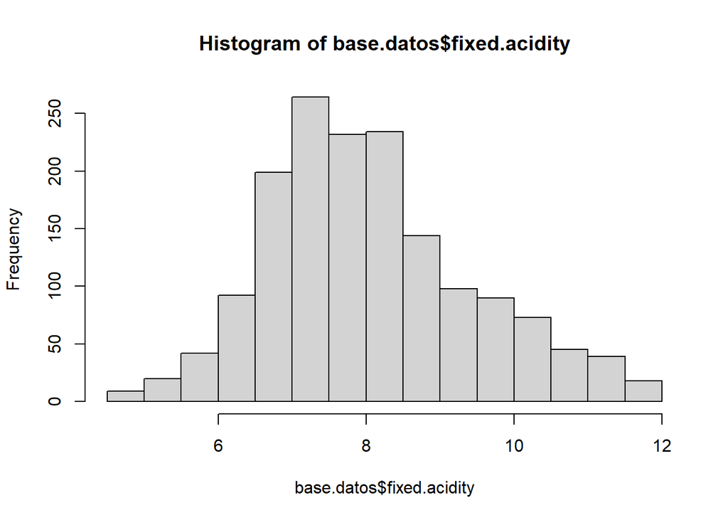

```r
# Representación en frecuencias (histogramas) de cada una de las variables que numéricas conforman el dataset :
hist(base.datos$fixed.acidity)
```

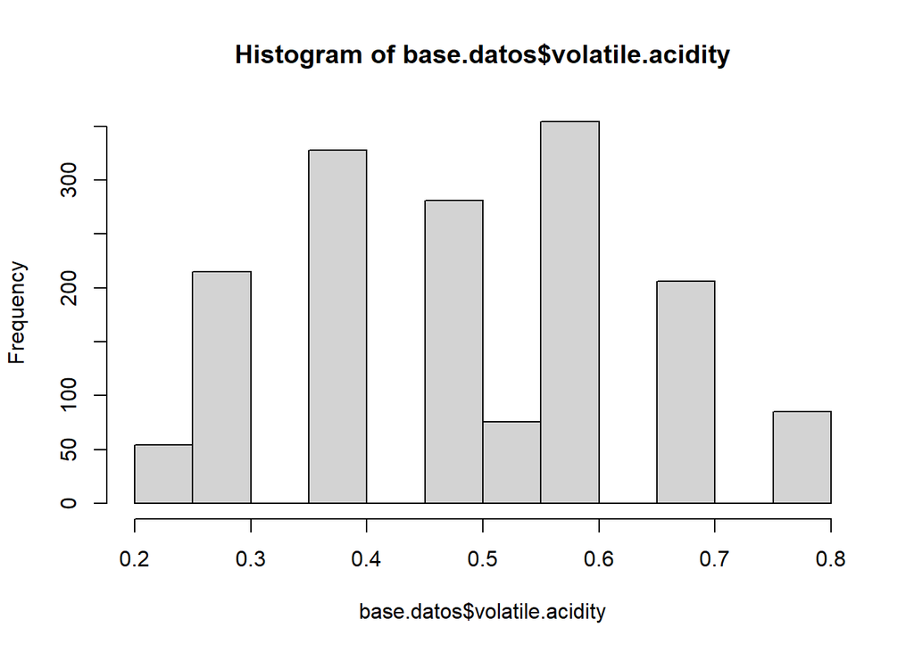

```r
hist(base.datos$volatile.acidity)
```

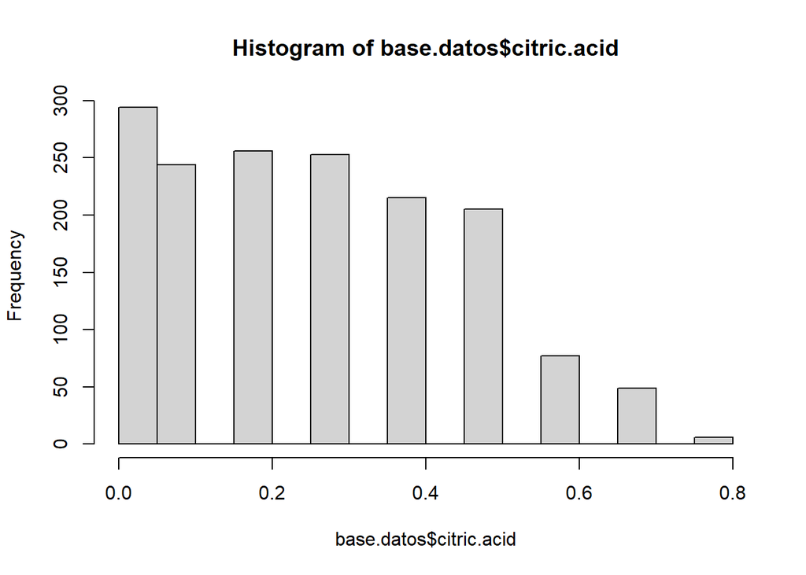

```r
hist(base.datos$citric.acid)
```

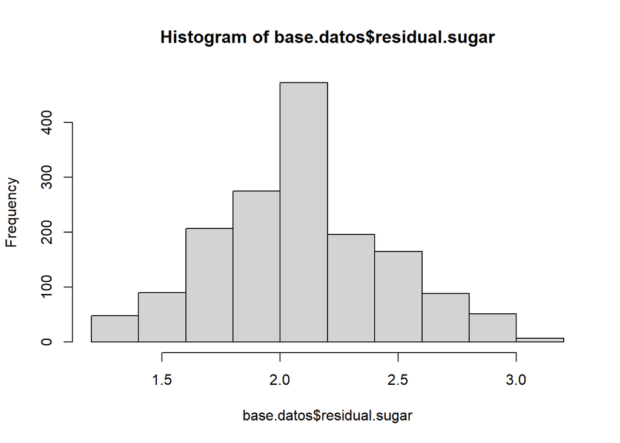

```r
hist(base.datos$residual.sugar)
```

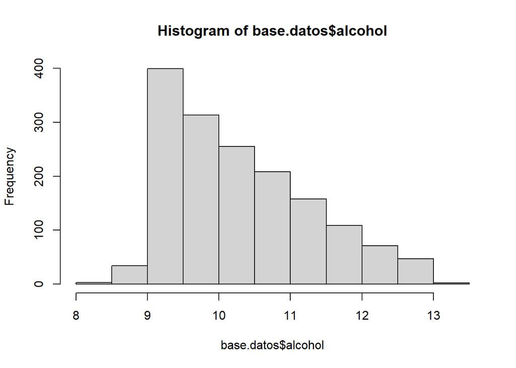

```r
hist(base.datos$alcohol)
```

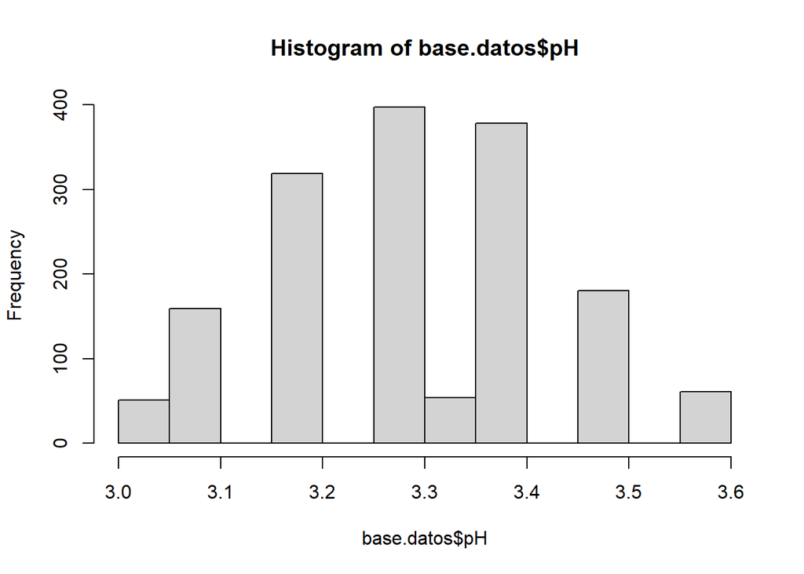

```r
hist(base.datos$pH)
```

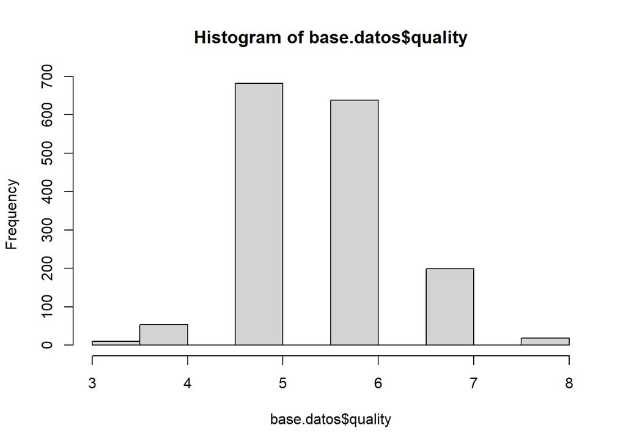

```r
hist(base.datos$quality)
```

```r
# Representación de la variable calidad_BM dicotómica por niveles:
table(base.datos$calidad_BM)
```

```
##
##    0    1
##   63 1536
```

A lo largo del análisis también se ha ido mostrando allí donde son necesarios otros plots/gráficos y documentación tanto visual como numérica de las diferentes variables que conforman la totalidad de nuestro dataset, por lo que realmente, la representación visual de la totalidad del Dataset no puede limitarse únicamente a dicho apartado, siendo este únicamente a modo resumen después del análisis llevado a cabo y las consideraciones pertinentes.

# 6. RESOLUCIÓN DEL PROBLEMA. CONCUSIONES

En línea con lo que se ha ido considerando y verificando a lo largo de la totalidad del documento y bajo las consideraciones inicialmente planteadas en torno a la calidad del vino según fuentes vitivinícolas fiables y de interés, presentamos la siguiente conslusión:

En diversas fuentes, encontramos como la acidez en un vino se puede asociar con la calidad de este. “Un vino debe su calidad en gran parte a su acidez”. A lo largo del toda la actividad, se ha trabajado en este concepto en base a las variables de las que disponíamos en nuestro conjunto de datos que podían influir en problema de investigación.

Concretamente, se escogió un subconjunto del mismo dataset para llevar a cabo la verificación y el análisis estadístico, no solo formado por las variables descriptoras de la acidez (fixed.acidity, volatile.acidity y citric.acid) sinó también por las variables pH, residual.sugar estos últimos parámetros se especulaba a través de considerables fuentes que también influyen en la calidad de un vino.

Una vez dispusimos de dichas variables, las tratamos en términos de Datos para poder llevar a cabo 4 pruebas estadísticas básicas para poder referirnos a nuestro problema inicial de investigación.

Primeraente, evaluamos la correlación total entre la totalidad de las variables de nuestro subconjunto, donde pudimos ver el grado de asociadión de estas, obteniendo pares de variables emparejadas y preparándo el análisis para la imposición de un modelo de regrasión lineal capaz de expliucar la calidad del vino.

El modelo lineal resultó con apenas una explicación de la calidad de un 27 % según el ajuste del modelo, lo que corresponde un valor bajo en términos de bondad de ajuste para un modelo pudiendo concluir que a priori, no podemos explicar calidad “quality” con la significancia marcada y introducida ni por las variables ácidas, ni por las demás añadidas posteriormente (según las consideraciones alcohol-acidez y azúcar-acidez que se comentaron inicialmente en la actividad y que podrían influir en la calidad de los vinos), en un modelo lineal múltiple.

En este punto, nos dispusimos a dicotomizar la variable quality en un nivel binario mediante la instauración de la variable calidad_BM. En este punto, pudimos llevar a cabo un modelo logístico, que tratase de indicarlos la probalilidad, en este caso, de obtener un vino de calidad (valor 1 de calidad_BM) en función de una serie de predictores, en línea a los que consideramos para formar el modelo lineal…

Tras la evaluación logística y la bondad de ajuste de modelo en términos de significancia, encontramos un modelo donde las variables fixed.acidity, citric.acid, residual.sugar y pH nos proporcionaban una correcta aproximación de la calidad de un vino. En este punto, nos acercamos más a la consideración de que la calidad en un vino venía asociada, en buena parte, a la calidad de este según las variable de acidez presentes en el modelo…

En este punto y focalizados en rebatir y/o ratificar las consideraciones iniciales tomadas desde diversas fuentes vitivinícolas en relación a la relación acidez-calidad de un vino y el resultado de la predicción logística, nos hemos dispuesto a evaluar, en una última instancia, un contraste de hipótesis sobre muestras referentes a alta calidad y baja calidad donde hemos visto y refutado hipótesis en relación a las 3 variables de acidez que disponíamos en nuestro dataset. Como resultado, hemos podido ver, en línea con la bodad del modelo logístico, como las variables de acidez fixed.acidity y citric.acid (esta última contenida dentro del mismo valor de acidez NO volátil del vino y por ende de fixed.acidity) se asocian con la intrepretación de la calidad del vino, pudiendo influir significativamente en esta y ratificando la idea general presentada en la introducción de la actividad cuando se expuso acerca de la calidad del vino.

Por otro lado, no podemos concluir con la misma idea para el nivel de acidez relativo a la acidez volátil de un vino (ácidos lácticos, acéticos, etc…), donde no hemos obtenido suficiente significancia para relacionas su justificación en la calidad de un vino, a priori, con los datos de los que hemos dispuesto de nuestro Dataset.

# 7. GUARDADO DEL FICHERO LIMPIO (CLEAN)

En este punto y por último, nos disponemos a guardar nuestro fichero base.datos debidamente modificado a lo largo de la actividad:

```r
# Defino la sentencia de guardado del documento en el directorio actual:
write.csv(base.datos, file = './WINE_CLEAN.csv')
```